# Ames Housing Models Problem Statement

Steven Slezak

31 March 2018

# 1 Introduction

The previous problem statement prepared for [the *Ames* housing data set](https://github.com/seslezak/Ames_Housing_Study/blob/master/Ames_Housing_README.md) covers the Exploratory Data Analysis done in preparation for building models based on the data. This problem statement addresses the modelling issues involved and will pick up where its predecessor left off. Little effort will be made to reproduce or repeat information from the first problem statement.

The goal here is to develop a set of models based on the *Ames* data, validate them, and assess their usefulness at predicting the value of houses in Ames, Iowa. Several preliminary results have been uploaded to Kaggle and [can be found there.](https://www.kaggle.com/c/house-prices-advanced-regression-techniques/submissions?sortBy=date&group=all&page=1) These results are from first draft models developed using linear regression, ridge regression, boost, and support vector machine methods.

This problem statement includes the following:

1. Introduction
2. Domain: Housing Data
3. Problem Statement: Use Machine Learning to Predict House Values
4. Description of Data Set: 2930 x 82 with a Mix of Nominal, Ordinal, Continuous, and Discrete Variables
5. Proposed Solution: PCR
6. Benchmark Model: Multiple Linear Regression
7. Performance Metrics: RMSE
8. Citations
9. Markdown Notebook with Associated Code

The problem statement and analysis utilize the *Ames* data sets [found here](https://www.openintro.org/stat/data/?data=ames) and [here.](https://www.kaggle.com/c/house-prices-advanced-regression-techniques/data)

# 2 Domain

The *Ames* data set is a collection of features characterizing houses sold in the Ames, Iowa, individual residential housing market between 2006 and 2010. The data come from the Office of the City Assessor, Ames, Iowa, and were used to compute assessment values for these properties.

# 3 Problem Statement

For the purpose of this study, *Ames* data are analyzed to develop models using ten different methodologies. Specifically,

1. Multiple Linear Regression
2. Multiple Linear Regression with Interactive Features
3. Ridge Regression
4. Lasso Regression
5. Primary Components Regression
6. Decision Trees
7. Bagging
8. Random Forest
9. Boosting
10. Support Vector Machine

Since the Kaggle competition evaluates results using the Root Mean Square Error (RMSE), which takes the square root of the MSE (Mean Square Error: *average (Y - Y<sub>hat</sub>)<sup>2</sup>*), this study will score model results using that metric. First-round results are summarized in Section 5 following.

Cross validated grid searches will be used to tune model parameters. An analysis based on Principle Component Regression will be used, along with other methods, to help determine the relative importance of the features in the *Ames* data set to preparing models.

Results given here represent an optimal combination of score and number of features for each model in each class. In selecting a model, it was necessary to run as many as ten variations of a particular model, adjusting features and tuning parameters along the way, to determine an optimal result. That is to say these are not necessarily the best results possible. They are simply the best results with a minimal number of features yielded by the models used. Since different variations on each model were run, results are referred to as “first round results.” All scores could be improved, some dramatically, by additional experimentation.

# 4 Description of Data Set

To summarize the previous problem statement, the *Ames* data consist of 82 features and 2930 observations. Features include two identifiers, 46 categorical, 14 discrete (such as year built), and 20 continuous (such as square footage) variables. Variables focus on the quality and quantity of physical attributes of the properties, and include final sales values.

The data set occupies 1.5 MB in memory.

# 5 Proposed Solution

Among the limited set of experiments run using the different model methodologies, the best solution identified is the Principle Components Regression model, which yielded an *RMSE* of 29,975.

The analysis find that any method other than linear regression and SVM offer more than adequate performance. Ensemble methods (Random Forest and Bagging) gave identical results, and Lasso and Ridge regressions results were very similar. Boosting was better than a single fitted decision tree, which itself exhibited a higher *RMSE* than either ensemble method.

Mulitlinear regression with and without interaction features yielded the same results.

The plot below illustrates the order of results from best to worst of the nine methods used. The results for both multilinear regression methods are combined in one bar.

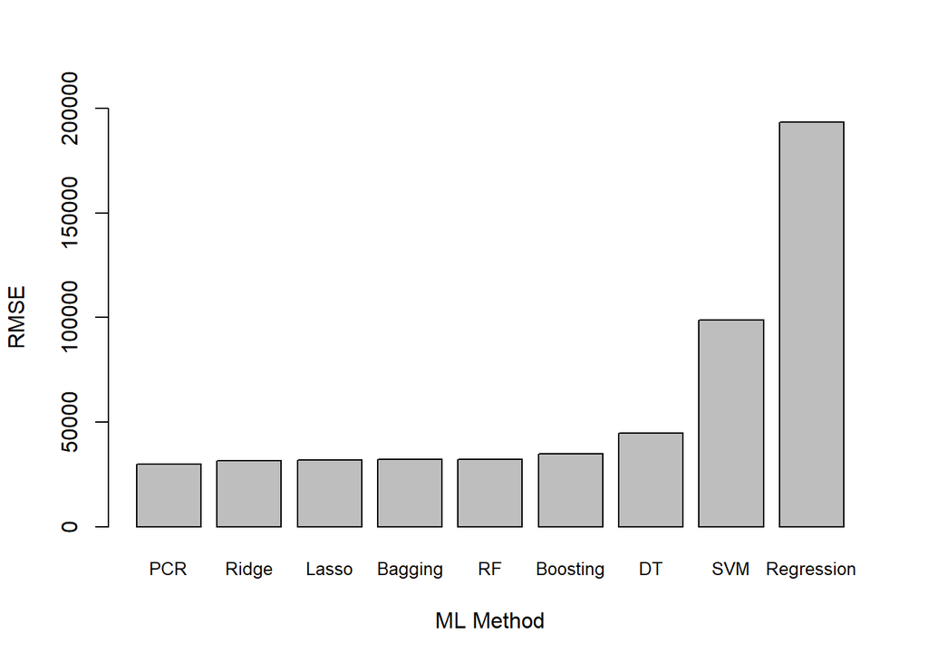

# 6 Benchmark Model

Ther benchmark for this study is multiple linear regression. The data set is well-suited to regression analysis, and the *Journal of Statistics Education* article<sup>1</sup> suggests students build a simple model and a more complicated version. In the simple model, it is suggested at least six variables be included in the analysis.

Our model utilizes 20 variables (as identified by feature importance selection), which are reduced to 15 through feature engineering. The literature targets a minimum *R<sup>2</sup>* value of 73%. Our benchmark achieves an *R<sup>2</sup>* value of 87%.

Regardless of this *R<sup>2</sup>* value, as seen in the chart above, the benchmark performs the worst among models with an *RMSE* of 193,543.

# 7 Performance Metrics

The article in the *Journal of Statistics Education*<sup>1</sup> suggests the following metrics be used to evaluate model performance:

1. Bias: *average (Y<sub>hat</sub> - Y)*
2. Maximium Deviation: *Max|Y - Y<sub>hat</sub>|*
3. Mean Absolute Deviation: *average |Y - Y<sub>hat</sub>|*
4. Mean Square Error: *average (Y - Y<sub>hat</sub>)<sup>2</sup>*

The Kaggle competition utilizes Root Mean Square Error, the square root of the MSE. We will use this metric for assessing results.

# 8 Citations

1. Dean De Cock, Ames, Iowa: Alternative to the Boston Housing Data as an End of Semester Regression Project. Journal of Statistics Education Volume 19, Number 3 (2011) [http://ww2.amstat.org/publications/jse/v19n3/decock.pdf]
2. Dean De Cock, Ames Housing Data Description. [https://ww2.amstat.org/publications/jse/v19n3/decock/DataDocumentation.txt]
3. OpenIntro Statistics [https://www.openintro.org/stat/data/?data=ames]
4. Package ‘AmesHousing’. R Documentation, 2017. [https://cran.r-project.org/web/packages/AmesHousing/AmesHousing.pdf]
5. *An Introduction to Statistical Learning: with Applications in R*. Gareth James, Daniela Witten, Trevor Hastie, Robert Tibshirani. Springer; 1st ed. 2013, Corr. 7th printing 2017 edition (September 1, 2017)
6. *Machine Learning Mastery* blog. Start with Gradient Boosting, Results from Comparing 13 Algorithms on 165 Datasets. Jason Brownlee, 30 March 2018.[https://machinelearningmastery.com/start-with-gradient-boosting/]
7. Randal S. Olson, William La Cava, Zairah Mustahsan, Akshay Varik, and Jason H. Moore, Data-driven Advice for Applying Machine Learning to Bioinformatics Problems. arXiv:1708.05070 [q-bio.QM] 7 Jan 2018 [https://arxiv.org/abs/1708.05070]
8. Manual Fernandez-Delgado, Eva Cernadas, Senen Barro, and Dinani Amorim. Do we Need Hundreds of Classifiers to Solve Real World Classification Problems? *Journal of Machine Learning Research* 15 (2014) 3133-3181. [http://www.jmlr.org/papers/volume15/delgado14a/delgado14a.pdf]

# 9 Markdown Notebooks

Two annotated Markdown Notebooks with associated *R* code and graphics can be [found here](https://seslezak.github.io/Ames_Housing_Study/Ames_Models_Pt01.html) and [here.](https://seslezak.github.io/Ames_Housing_Study/Ames_Models_Pt02.html)

The full *R* code can be [found on GitHub](https://github.com/seslezak/Ames_Housing_Study/tree/master/ipynb).